# bookingproject

Hotel Booking Comprehensive Data Analysis

1. Import the pandas library, seaborn and pyplot from matplotlib. Load the bookings.csv dataset with the separator ;.

```python
import pandas as pd
import seaborn as sns
import matplotlib.pyplot as plt
```

2. Check the size of the table, data types, and then output the first 7 rows to view the data.

```python
df = pd.read_csv(r'C:\Users\user\Downloads\bookings.csv',encoding = 'windows-1251', sep=';')
```

```python
df.shape
```

```
(119390, 21)
```

```python
df.info()
```

```
<class 'pandas.core.frame.DataFrame'>
RangeIndex: 119390 entries, 0 to 119389
Data columns (total 21 columns):
 #   Column                     Non-Null Count   Dtype
---  ------                     --------------   -----
 0   Hotel                      119390 non-null  object
 1   Is Canceled                119390 non-null  int64
 2   Lead Time                  119390 non-null  int64
 3   arrival full date          119390 non-null  object
 4   Arrival Date Year          119390 non-null  int64
 5   Arrival Date Month         119390 non-null  object
 6   Arrival Date Week Number   119390 non-null  int64
 7   Arrival Date Day of Month  119390 non-null  int64
 8   Stays in Weekend nights    119390 non-null  int64
 9   Stays in week nights       119390 non-null  int64
 10  stays total nights         119390 non-null  int64
 11  Adults                     119390 non-null  int64
 12  Children                   119386 non-null  float64
 13  Babies                     119390 non-null  int64
 14  Meal                       119390 non-null  object
 15  Country                    118902 non-null  object
 16  Reserved Room Type         119390 non-null  object
 17  Assigned room type         119390 non-null  object
 18  customer type              119390 non-null  object
 19  Reservation Status         119390 non-null  object
 20  Reservation status_date    119390 non-null  object
dtypes: float64(1), int64(10), object(10)
memory usage: 19.1+ MB
```

```python
df.head(7)
```

|  | Hotel | Is Canceled | Lead Time | arrival full date | Arrival Date Year | Arrival Date Month | Arrival Date Week Number | Arrival Date Day of Month | Stays in Weekend nights | Stays in week nights | ... | Adults | Children | Babies | Meal | Country | Reserved Room Type | Assigned room type | customer type | Reservation Status | Reservation status_date |
| --- | --- | --- | --- | --- | --- | --- | --- | --- | --- | --- | --- | --- | --- | --- | --- | --- | --- | --- | --- | --- | --- |
| 0 | Resort Hotel | 0 | 342 | 2015-07-01 | 2015 | July | 27 | 1 | 0 | 0 | ... | 2 | 0.0 | 0 | BB | PRT | C | C | Transient | Check-Out | 2015-07-01 |
| 1 | Resort Hotel | 0 | 737 | 2015-07-01 | 2015 | July | 27 | 1 | 0 | 0 | ... | 2 | 0.0 | 0 | BB | PRT | C | C | Transient | Check-Out | 2015-07-01 |
| 2 | Resort Hotel | 0 | 7 | 2015-07-01 | 2015 | July | 27 | 1 | 0 | 1 | ... | 1 | 0.0 | 0 | BB | GBR | A | C | Transient | Check-Out | 2015-07-02 |
| 3 | Resort Hotel | 0 | 13 | 2015-07-01 | 2015 | July | 27 | 1 | 0 | 1 | ... | 1 | 0.0 | 0 | BB | GBR | A | A | Transient | Check-Out | 2015-07-02 |
| 4 | Resort Hotel | 0 | 14 | 2015-07-01 | 2015 | July | 27 | 1 | 0 | 2 | ... | 2 | 0.0 | 0 | BB | GBR | A | A | Transient | Check-Out | 2015-07-03 |
| 5 | Resort Hotel | 0 | 14 | 2015-07-01 | 2015 | July | 27 | 1 | 0 | 2 | ... | 2 | 0.0 | 0 | BB | GBR | A | A | Transient | Check-Out | 2015-07-03 |
| 6 | Resort Hotel | 0 | 0 | 2015-07-01 | 2015 | July | 27 | 1 | 0 | 2 | ... | 2 | 0.0 | 0 | BB | PRT | C | C | Transient | Check-Out | 2015-07-03 |

7 rows × 21 columns

3. Rename the column names to lowercase and replace spaces with underscores.

```python
df.columns
```

```
Index(['Hotel', 'Is Canceled', 'Lead Time', 'arrival full date',
       'Arrival Date Year', 'Arrival Date Month', 'Arrival Date Week Number',
       'Arrival Date Day of Month', 'Stays in Weekend nights',
       'Stays in week nights', 'stays total nights', 'Adults', 'Children',
       'Babies', 'Meal', 'Country', 'Reserved Room Type', 'Assigned room type',
       'customer type', 'Reservation Status', 'Reservation status_date'],
      dtype='object')
```

```python
#роблю пустий словник
rename_cols = {}
#за допомогою цикла for заміню пробіли на підкреслення та приведу назви колонок до нижнього регістру
for i in df.columns:
    rename_cols[i] = i.replace(' ', '_').lower()
```

```python
rename_cols
```

```
{'Hotel': 'hotel',
 'Is Canceled': 'is_canceled',
 'Lead Time': 'lead_time',
 'arrival full date': 'arrival_full_date',
 'Arrival Date Year': 'arrival_date_year',
 'Arrival Date Month': 'arrival_date_month',
 'Arrival Date Week Number': 'arrival_date_week_number',
 'Arrival Date Day of Month': 'arrival_date_day_of_month',
 'Stays in Weekend nights': 'stays_in_weekend_nights',
 'Stays in week nights': 'stays_in_week_nights',
 'stays total nights': 'stays_total_nights',
 'Adults': 'adults',
 'Children': 'children',
 'Babies': 'babies',
 'Meal': 'meal',
 'Country': 'country',
 'Reserved Room Type': 'reserved_room_type',
 'Assigned room type': 'assigned_room_type',
 'customer type': 'customer_type',
 'Reservation Status': 'reservation_status',
 'Reservation status_date': 'reservation_status_date'}
```

```python
df1 = df.rename(columns = rename_cols)
df1.columns
```

```
Index(['hotel', 'is_canceled', 'lead_time', 'arrival_full_date',
       'arrival_date_year', 'arrival_date_month', 'arrival_date_week_number',
       'arrival_date_day_of_month', 'stays_in_weekend_nights',
       'stays_in_week_nights', 'stays_total_nights', 'adults', 'children',
       'babies', 'meal', 'country', 'reserved_room_type', 'assigned_room_type',
       'customer_type', 'reservation_status', 'reservation_status_date'],
      dtype='object')
```

4. Which countries have made the most successful bookings? Show the top 5.

```python
df1.loc[df1.is_canceled == 0].country.value_counts().head(5)
```

```
country
PRT    21071
GBR     9676
FRA     8481
ESP     6391
DEU     6069
Name: count, dtype: int64
```

5. Visualization of the Top-5 countries with the most successful bookings: For this, I use a bar plot from the Seaborn or Matplotlib library to clearly show the top countries.

```python
top_5_countries = df1.loc[df1.is_canceled == 0].country.value_counts().head(5)
```

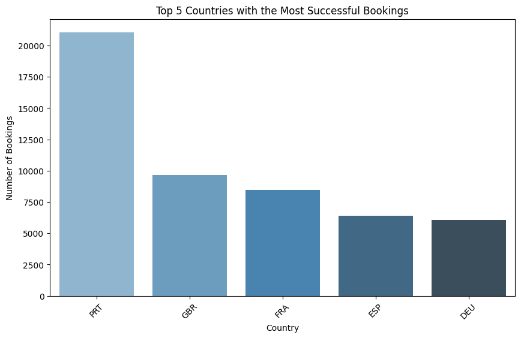

```python
plt.figure(figsize=(10, 6))
sns.barplot(x=top_5_countries.index, y=top_5_countries.values, palette='Blues_d')
plt.title('Top 5 Countries with the Most Successful Bookings')
plt.xlabel('Country')
plt.ylabel('Number of Bookings')
plt.xticks(rotation=45)
plt.show()
```

```python
df1.groupby('hotel').stays_total_nights.mean().round(2)
```

```
hotel
City Hotel      2.98
Resort Hotel    4.32
Name: stays_total_nights, dtype: float64
```

```python
len(df1.loc[df1.assigned_room_type != df1.reserved_room_type])
```

```
14917
```

```python
df1.groupby('arrival_date_year').arrival_date_month.agg(pd.Series.mode)
```

```
arrival_date_year
2015    September
2016      October
2017          May
Name: arrival_date_month, dtype: object
```

```python
df1.groupby(['arrival_date_year','arrival_date_month']).is_canceled.sum()
```

```
arrival_date_year  arrival_date_month
2015               August                1598
                   December               973
                   July                  1259
                   November               486
                   October               1732
                   September             2094
2016               April                 2061
                   August                1825
                   December              1398
                   February              1337
                   January                557
                   July                  1499
                   June                  2096
                   March                 1477
                   May                   1915
                   November              1636
                   October               2514
                   September             2022
2017               April                 2463
                   August                1816
                   February              1359
                   January               1250
                   July                  1984
                   June                  2439
                   March                 1672
                   May                   2762
Name: is_canceled, dtype: int64
```

```python
df1.groupby(['arrival_date_year','arrival_date_month']).is_canceled.sum().groupby(['arrival_date_year']).nlargest(1)
```

```
arrival_date_year  arrival_date_year  arrival_date_month
2015               2015               September             2094
2016               2016               October               2514
2017               2017               May                   2762
Name: is_canceled, dtype: int64
```

7. Changes in the popularity of months for bookings in 2016 and 2017. Visualizing the changes in month popularity for each year will help understand the trends.

```python
month_popularity = df1.groupby(['arrival_date_year', 'arrival_date_month']).size().unstack()
```

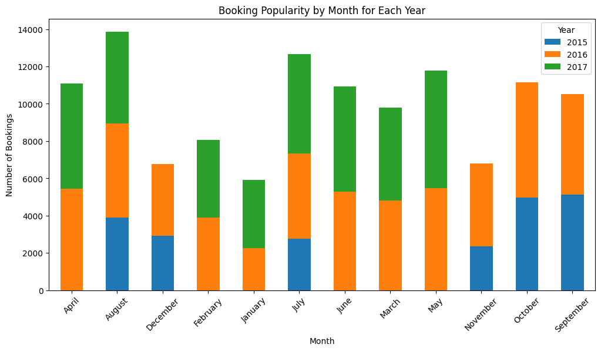

```python
plt.figure(figsize=(12, 6))
month_popularity.T.plot(kind='bar', stacked=True, figsize=(12, 6))
plt.title('Booking Popularity by Month for Each Year')
plt.xlabel('Month')
plt.ylabel('Number of Bookings')
plt.xticks(rotation=45)
plt.legend(title='Year')
plt.show()
```

8. Average number of nights by hotel types. Сreate a plot to compare the average number of nights in City Hotels and Resort Hotels.

```python
avg_nights = df1.groupby('hotel').stays_total_nights.mean()
```

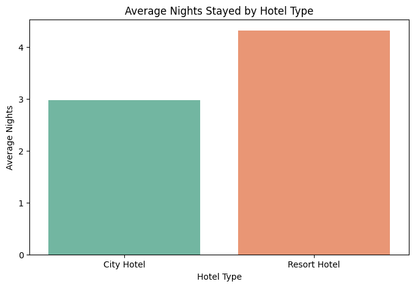

```python
plt.figure(figsize=(8, 5))
sns.barplot(x=avg_nights.index, y=avg_nights.values, palette='Set2')
plt.title('Average Nights Stayed by Hotel Type')
plt.xlabel('Hotel Type')
plt.ylabel('Average Nights')
plt.show()
```

9. Visualization of the frequency of room types for booked and provided. I show the discrepancies between the booked and provided room types. For this, I create a chart that shows the number of such discrepancies.

```python
room_type_diff = df1.loc[df1.assigned_room_type != df1.reserved_room_type].groupby('reserved_room_type').size()
```

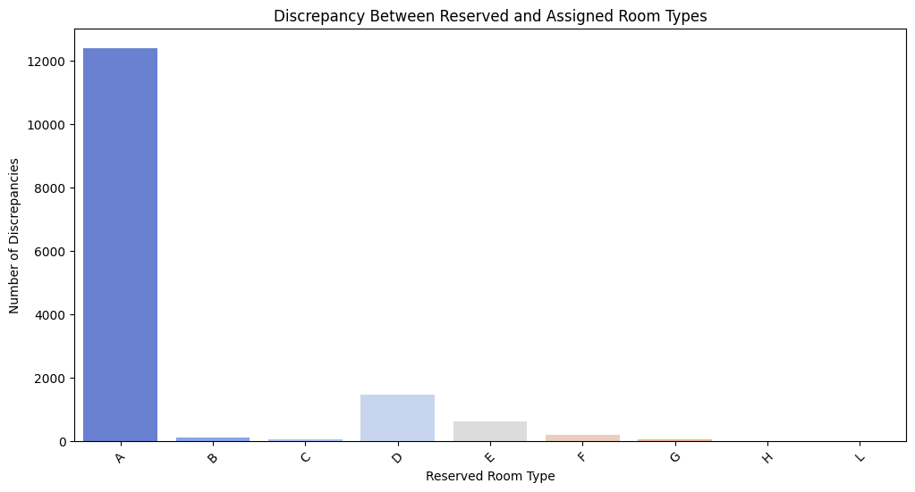

```python
plt.figure(figsize=(12, 6))
sns.barplot(x=room_type_diff.index, y=room_type_diff.values, palette='coolwarm')
plt.title('Discrepancy Between Reserved and Assigned Room Types')
plt.xlabel('Reserved Room Type')
plt.ylabel('Number of Discrepancies')
plt.xticks(rotation=45)
plt.show()
```

10. Look at the numeric statistics for the variables adults, children, and babies. Which one has the highest mean value?

```python
df1[['adults', 'children','babies']].mean()
```

```
adults      1.856403
children    0.103890
babies      0.007949
dtype: float64
```

11. Create a new column total_kids, combining children and babies. Which type of hotels are more popular with clients with children? Create a variable has_kids, which is True if the client has at least one child, and False otherwise. Calculate the churn rate, i.e., the percentage of cancellations for clients with and without kids. Which group has a higher churn rate?

```python
 df1['total_kids'] = df1.children + df1.babies
 df1.total_kids.dtypes
```

```
dtype('float64')
```

```python
df1.groupby('hotel').total_kids.mean().round(2)
```

```
hotel
City Hotel      0.10
Resort Hotel    0.14
Name: total_kids, dtype: float64
```

```python
def has_kids(x):
    if x>0:
        return True
    else:
        return False
```

```python
df1['has_kids'] = df1.total_kids.apply(has_kids)
```

```python
df1['has_kids']
```

```
0         False
1         False
2         False
3         False
4         False
          ...
119385    False
119386    False
119387    False
119388    False
119389    False
Name: has_kids, Length: 119390, dtype: bool
```

```python
df1[['has_kids', 'is_canceled']].value_counts() / df1[['has_kids']].value_counts() *100
```

```
has_kids  is_canceled
False     0              62.778717
          1              37.221283
True      0              65.077154
          1              34.922846
Name: count, dtype: float64
```

12. Cancellation frequency of bookings for users with children. Visualizing the cancellation frequency for the group of users with children will help to visually assess the issue.

```python
cancellations_with_kids = df1.groupby('has_kids').is_canceled.mean() * 100
```

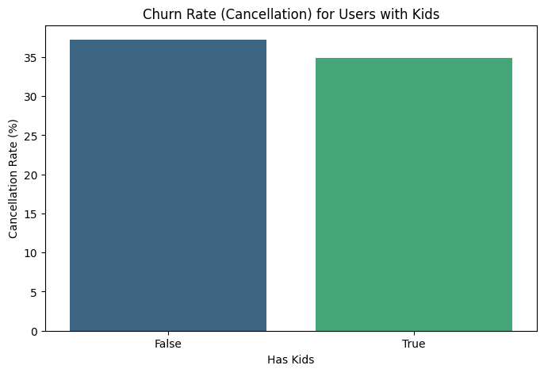

```python
plt.figure(figsize=(8, 5))
sns.barplot(x=cancellations_with_kids.index, y=cancellations_with_kids.values, palette='viridis')
plt.title('Churn Rate (Cancellation) for Users with Kids')
plt.xlabel('Has Kids')
plt.ylabel('Cancellation Rate (%)')
plt.show()
```

13. Visualize the cancellation rates for the two groups: those with children and those without.

To do this, I use a bar plot to show the percentage of cancellations for each group:

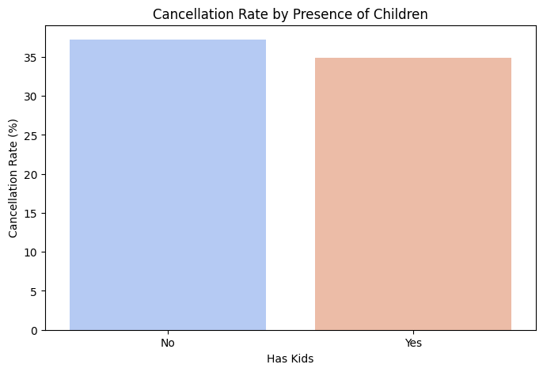

```python
# Grouping by the presence of children (has_kids) and calculating cancellation percentages
cancellation_rate = df1.groupby('has_kids')['is_canceled'].mean() * 100

# Plotting the cancellation rates
plt.figure(figsize=(8, 5))
sns.barplot(x=cancellation_rate.index, y=cancellation_rate.values, palette='coolwarm')
plt.title('Cancellation Rate by Presence of Children')
plt.xlabel('Has Kids')
plt.ylabel('Cancellation Rate (%)')
plt.xticks(ticks=[0, 1], labels=['No', 'Yes'])
plt.show()
```

14. I already created a has_kids column to track whether a guest has children, and now I can use that to determine which type of hotel (City or Resort) is more popular with clients with children. To visualize this, I can plot the number of bookings for each hotel type for clients with children:

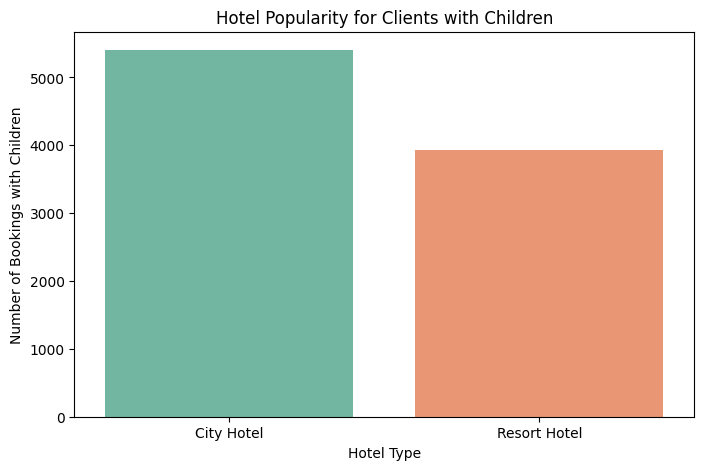

```python
# Counting the number of bookings for each hotel type where 'has_kids' is True
hotel_popularity_with_kids = df1[df1['has_kids']].groupby('hotel').size()

# Plotting the popularity of hotels with kids
plt.figure(figsize=(8, 5))
sns.barplot(x=hotel_popularity_with_kids.index, y=hotel_popularity_with_kids.values, palette='Set2')
plt.title('Hotel Popularity for Clients with Children')
plt.xlabel('Hotel Type')
plt.ylabel('Number of Bookings with Children')
plt.show()
```

This will give me a clear picture of whether City Hotels or Resort Hotels are more popular among guests with children.